# assignment_06

Katy Gardner

3/9/2021

# Assignment 06: Building my SQLite database

```r
#load packages
library(DBI)
library(RSQLite)
library(dplyr)
library(tidyverse)
library(lessR)
library(tibble)
```

For my project, I have 4 main .csv files that I want to incorporate into one database. The files pertain to two main entities: the tanks and the bugs. Tanks contain bugs in certain treatment conditions (temperature and added sulfate). There are 3 sampling processes going on: tanks, bugs, and chemical analyses. Chemical analyses are conducted prior to the start of the experiment and at the end of the experiment. Tanks are measured approximately twice a week (with some variability) for dissolved oxygen, conductivity, and temperature levels as a sort of maintenance measurement. The number of bugs alive per tank is measured once a week and recorded as that tank’s survival. Finally, bugs are measured once every two weeks for head capsule width, which can then be converted to a specific growth measurement. The database structure I intend to follow is displayed below.

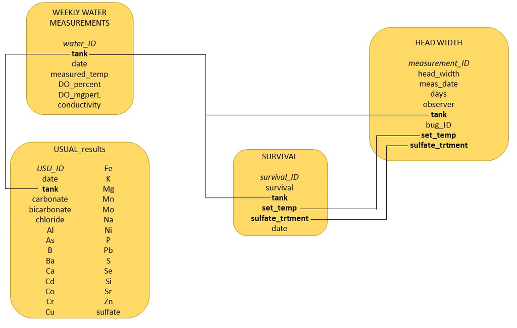

Database structure. Italics denote primary key, bold denotes foreign keys.

### Creating the database

First, I will create a database connection in the “project” folder of my Reproducible Science class folder.

```r
#establish a database connection
ptery_sulf_db <- dbConnect(drv = RSQLite::SQLite(),
                        "../../project/ptery_sulf.db")
```

Next, I want to load in all of the .csv files I intend to add to the database. I’ll start with USUAL water measurement data.

```r
USUAL_start <- read.csv("../../../../Research/experiments/sulfate/pteronarcys/raw_data/2020-07_USUAL_results.csv")
USUAL_end <- read.csv("../../../../Research/experiments/sulfate/pteronarcys/raw_data/2021-01_USUAL_results.csv")
#original USUAL docs had "<" when measurement values were below detection limits (typically <0.001)
#I replaced "<" with empty cells for R purposes. Not sure if empty/blank cells are more appropriate than 0's?
```

We want to combine these two USUAL .csv files into one for the database. Some cleaning needs to be done before merging the two files. Additionally, carbonate and bicarbonate were only measured in the second round of tests (“end”), so these columns will need to be added to the first document.

```r
USUAL_start <- USUAL_start %>%
  rename(USU_ID = ï..USU_ID,
         Sulfate = Sulfate.Sulfur,
         arsenic = As) #renaming columns that imported into R poorly

USUAL_start <- USUAL_start[1:37, ] #deleting empty rows that were for some reason included in the csv import

USUAL_start <- add_column(USUAL_start, date = rep(as.Date("2020-07-27"),37), .after = 1) #add in date of water sample to differentiate between start and end

USUAL_end <- USUAL_end %>%
  rename(USU_ID = ï..USU_ID,
         Sulfate = Sulfate.Sulfur,
         arsenic = As, #for some reason RSQLite won't create table with this column name as As
         carbonate = Carbonate_mmolc.L,
         bicarbonate = Bicarbonate_mmolc.L) #the "." in the original name not SQL friendly

USUAL_end <- USUAL_end[1:36, ] #USUAL_end has one fewer rows because we did not test the well water a second time

USUAL_end <- add_column(USUAL_end, date = rep(as.Date("2021-01-07"),36), .after = 1)

empty_cols <- c("carbonate", "bicarbonate") #adding empty columns before vertically merging
USUAL_start[, empty_cols] <- NA

#merge files vertically
usual <- Merge(USUAL_start, USUAL_end, by="rows")
```

Let’s add the USUAL dataframe into our database.

```r
#write table in database
dbExecute(ptery_sulf_db, "CREATE TABLE usual (
          USU_ID float NOT NULL PRIMARY KEY,
          date text,
          Trough integer,
          Tank integer,
          Chloride float,
          Al float,
          arsenic float,
          B float,
          Ba float,
          Ca float,
          Cd float,
          Co float,
          Cr float,
          Cu float,
          Fe float,
          K float,
          Mg float,
          Mn float,
          Mo float,
          Na float,
          Ni float,
          P float,
          Pb float,
          S float,
          Se float,
          Si float,
          Sr float,
          Zn float,
          Sulfate float,
          carbonate float,
          bicarbonate float);")
```

```
## [1] 0
```

```r
dbWriteTable(ptery_sulf_db, "usual", usual, append = TRUE)
```

With the table added, let’s check to see that it worked before moving on to the other 3 tables.

```r
dbListTables(ptery_sulf_db)
```

```
## [1] "usual"
```

```r
dbGetQuery(ptery_sulf_db, "SELECT * FROM usual LIMIT 10;")
```

```
##    USU_ID    date Trough Tank Chloride Al arsenic     B Ba     Ca Cd    Co
## 1    2333 18470.0      1    1     3.42 NA   0.006 0.004 NA   6.29 NA    NA
## 2    2334 18470.0      1    2     2.37 NA   0.005 0.004 NA 104.00 NA 0.001
## 3    2335 18470.0      1    3     2.68 NA   0.004 0.005 NA 242.00 NA 0.001
## 4    2336 18470.0      1    4     2.40 NA      NA 0.003 NA  54.80 NA    NA
## 5    2337 18470.0      1    5     2.45 NA   0.003 0.004 NA 195.00 NA 0.001
## 6    2338 18470.0      1    6     2.57 NA   0.002 0.003 NA 151.00 NA    NA
## 7    2339 18470.0      2    7     2.36 NA   0.004 0.004 NA 148.00 NA    NA
## 8    2340 18470.0      2    8     2.42 NA   0.006 0.002 NA  56.10 NA    NA
## 9    2341 18470.0      2    9     2.38 NA   0.004 0.002 NA   6.70 NA    NA
## 10   2342 18470.0      2   10     2.33 NA   0.002 0.004 NA 101.00 NA 0.001
##       Cr    Cu Fe    K     Mg    Mn Mo   Na    Ni  P    Pb      S Se   Si   Sr
## 1     NA 0.003 NA 0.17   2.13    NA NA 0.93    NA NA 0.001   0.61 NA 0.76 0.02
## 2     NA 0.002 NA 0.18  44.10    NA NA 0.88    NA NA    NA 138.00 NA 0.86 0.03
## 3     NA    NA NA 0.30 105.00 0.002 NA 0.89    NA NA    NA 338.00 NA 0.82 0.06
```

[output cut: 18 more lines]

Sweet! It worked! Adding the other .csv files below.

```r
survival.wide <- read.csv("../../../../Research/experiments/sulfate/pteronarcys/raw_data/weekly_survival.csv")

#this file is in wide form, let's switch it to a more r-friendly long-form

survival <- gather(survival.wide, sdate, survival, na.rm = F, X28.Jul:X28.Dec)



survival$Sulfate.mg.L <- as.character(survival$Sulfate.mg.L)

survival <- survival %>%
  mutate(sdate2 = dplyr::recode(sdate,                     # note use of dplyr::
                                X28.Jul  = "2020-07-28",
                                X3.Aug = "2020-08-03",
                                X10.Aug = "2020-08-10",
                                X17.Aug = "2020-08-17",
                                X24.Aug = "2020-08-24",
                                X31.Aug = "2020-08-31",
                                X8.Sep = "2020-09-08",
                                X14.Sep = "2020-09-14",
                                X21.Sep = "2020-09-21",
                                X28.Sep = "2020-09-28",
                                X5.Oct = "2020-10-05",
                                X12.Oct = "2020-10-12",
                                X19.Oct = "2020-10-19",
                                X26.Oct = "2020-10-26",
                                X2.Nov = "2020-11-02",
                                X9.Nov = "2020-11-09",
                                X16.Nov = "2020-11-16",
                                X23.Nov = "2020-11-23",
                                X30.Nov = "2020-11-30",
                                X7.Dec = "2020-12-07",
                                X14.Dec = "2020-12-14",
                                X21.Dec = "2020-12-21",
                                X28.Dec = "2020-12-28"))


with(survival, table(sdate2, sdate)) # a check to make sure therer are 36 values at each old date and recoded date
```

```
##             sdate
## sdate2       X10.Aug X12.Oct X14.Dec X14.Sep X16.Nov X17.Aug X19.Oct X2.Nov
##   2020-07-28       0       0       0       0       0       0       0      0
##   2020-08-03       0       0       0       0       0       0       0      0
##   2020-08-10      36       0       0       0       0       0       0      0
##   2020-08-17       0       0       0       0       0      36       0      0
##   2020-08-24       0       0       0       0       0       0       0      0
##   2020-08-31       0       0       0       0       0       0       0      0
##   2020-09-08       0       0       0       0       0       0       0      0
##   2020-09-14       0       0       0      36       0       0       0      0
##   2020-09-21       0       0       0       0       0       0       0      0
##   2020-09-28       0       0       0       0       0       0       0      0
##   2020-10-05       0       0       0       0       0       0       0      0
##   2020-10-12       0      36       0       0       0       0       0      0
##   2020-10-19       0       0       0       0       0       0      36      0
##   2020-10-26       0       0       0       0       0       0       0      0
##   2020-11-02       0       0       0       0       0       0       0     36
##   2020-11-09       0       0       0       0       0       0       0      0
##   2020-11-16       0       0       0       0      36       0       0      0
##   2020-11-23       0       0       0       0       0       0       0      0
##   2020-11-30       0       0       0       0       0       0       0      0
##   2020-12-07       0       0       0       0       0       0       0      0
##   2020-12-14       0       0      36       0       0       0       0      0
##   2020-12-21       0       0       0       0       0       0       0      0
##   2020-12-28       0       0       0       0       0       0       0      0
##             sdate
## sdate2       X21.Dec X21.Sep X23.Nov X24.Aug X26.Oct X28.Dec X28.Jul X28.Sep
##   2020-07-28       0       0       0       0       0       0      36       0
##   2020-08-03       0       0       0       0       0       0       0       0
##   2020-08-10       0       0       0       0       0       0       0       0
##   2020-08-17       0       0       0       0       0       0       0       0
##   2020-08-24       0       0       0      36       0       0       0       0
##   2020-08-31       0       0       0       0       0       0       0       0
##   2020-09-08       0       0       0       0       0       0       0       0
##   2020-09-14       0       0       0       0       0       0       0       0
##   2020-09-21       0      36       0       0       0       0       0       0
##   2020-09-28       0       0       0       0       0       0       0      36
##   2020-10-05       0       0       0       0       0       0       0       0
##   2020-10-12       0       0       0       0       0       0       0       0
##   2020-10-19       0       0       0       0       0       0       0       0
```

[output cut: 20 more lines]

```
##   2020-09-21      0       0       0      0      0      0      0
##   2020-09-28      0       0       0      0      0      0      0
##   2020-10-05      0       0       0     36      0      0      0
##   2020-10-12      0       0       0      0      0      0      0
##   2020-10-19      0       0       0      0      0      0      0
##   2020-10-26      0       0       0      0      0      0      0
##   2020-11-02      0       0       0      0      0      0      0
##   2020-11-09      0       0       0      0      0      0     36
##   2020-11-16      0       0       0      0      0      0      0
##   2020-11-23      0       0       0      0      0      0      0
##   2020-11-30      0      36       0      0      0      0      0
##   2020-12-07      0       0       0      0     36      0      0
##   2020-12-14      0       0       0      0      0      0      0
##   2020-12-21      0       0       0      0      0      0      0
##   2020-12-28      0       0       0      0      0      0      0
```

```r
survival <- survival %>%
  rename(sulfate_trtment = Sulfate.mg.L,
         date = sdate2,
         set_temp = Temperature,
         tank = Tank) #renaming columns that imported into R poorly

survival <- survival[,c(2:4,6:7)]

survival$survival_ID <- 1:nrow(survival) #add a serial no. column to act as unique primary key

survival <- survival[, c("survival_ID", "date", "tank", "set_temp", "sulfate_trtment", "survival")] #reordering columns
```

Write the survival table into database.

```r
dbExecute(ptery_sulf_db, "CREATE TABLE survival (
          survival_ID integer NOT NULL PRIMARY KEY,
          date text,
          tank integer,
          set_temp integer,
          sulfate_trtment integer,
          survival integer,
          FOREIGN KEY(tank) REFERENCES usual(tank));")
```

```
## [1] 0
```

```r
dbWriteTable(ptery_sulf_db, "survival", survival, append = TRUE)
dbListTables(ptery_sulf_db)
```

```
## [1] "survival" "usual"
```

```r
dbGetQuery(ptery_sulf_db, "SELECT * FROM survival LIMIT 10;")
```

```
##    survival_ID       date tank set_temp sulfate_trtment survival
## 1            1 2020-07-28    1       14               0       10
## 2            2 2020-07-28    2       14             400       10
## 3            3 2020-07-28    3       14            1000       10
## 4            4 2020-07-28    4       14             200       10
## 5            5 2020-07-28    5       14             800       10
## 6            6 2020-07-28    6       14             600       10
## 7            7 2020-07-28    7       22             600       10
## 8            8 2020-07-28    8       22             200       10
## 9            9 2020-07-28    9       22               0       10
## 10          10 2020-07-28   10       22             400       10
```

Add weekly water measurement data. NOTE: This data has not all been entered yet, so this data file is really incomplete. Will need to go back and re-add to database when all data has been entered.

```r
water_meas <- read.csv("../../../../Research/experiments/sulfate/pteronarcys/raw_data/weekly_water_measurements.csv")

#rename some columns
water_meas <- water_meas %>%
  rename(date = ï..DATE,
         measured_temp = TEMP..C.,
         DO_percent = DO.,
         DO_mgL = DO..mg.L.,
         conductivity = CONDUCTIVITY,
         tank = TANK)

#add a serial no. column to act as unique primary key, put it as first column
water_meas <- add_column(water_meas, water_ID = 1:nrow(water_meas), .after = 0)
```

Create water_measures table in SQLite.

```r
dbExecute(ptery_sulf_db, "CREATE TABLE water_measures (
          water_ID integer NOT NULL PRIMARY KEY,
          date text,
          tank integer,
          measured_temp float,
          DO_percent float,
          DO_mgL float,
          conductivity integer,
          FOREIGN KEY(tank) REFERENCES survival(tank));")
```

```
## [1] 0
```

```r
dbWriteTable(ptery_sulf_db, "water_measures", water_meas, append = TRUE)
dbListTables(ptery_sulf_db)
```

```
## [1] "survival"       "usual"          "water_measures"
```

```r
dbGetQuery(ptery_sulf_db, "SELECT * FROM water_measures LIMIT 10;")
```

```
##    water_ID      date tank measured_temp DO_percent DO_mgL conductivity
## 1         1 7/29/2020    1          15.4       77.7   7.77           60
## 2         2 7/29/2020    2          15.4       82.6   8.26          815
## 3         3 7/29/2020    3          15.5       82.5   8.24         1685
## 4         4 7/29/2020    4          15.4       83.8   8.38          485
## 5         5 7/29/2020    5          15.3       83.5   8.37         1395
## 6         6 7/29/2020    6          14.8       84.0   8.50         1100
## 7         7 7/29/2020    7          21.4       83.8   7.46         1165
## 8         8 7/29/2020    8          21.3       82.2   7.38          510
## 9         9 7/29/2020    9          21.4       83.1   7.39           70
## 10       10 7/29/2020   10          21.5       84.6   7.47          850
```

Import head width data.

```r
head_width <- read.csv("../../../../Research/experiments/sulfate/pteronarcys/raw_data/head-width_measurements.csv")

#rename some columns
head_width <- head_width %>%
  rename(meas_date = DATE,
         week = WEEK,
         observer = MEASURED_BY,
         bug_ID = ID,
         tank = TANK,
         head_width = HEAD_WIDTH)

#add a serial no. column to act as unique primary key, put it as first column
head_width <- add_column(head_width, meas_ID = 1:nrow(head_width), .after = 0)

#eliminate the "ZOOM" and "MICROMETER UNITS" columns (not needed for db)
head_width <- head_width[,c(1:4, 6:7,10)]
```

Create head_width table in SQLite.

```r
dbExecute(ptery_sulf_db, "CREATE TABLE head_width (
          meas_ID integer NOT NULL PRIMARY KEY,
          week integer,
          meas_date text,
          observer text,
          tank integer,
          bug_ID varchar(4),
          head_width float,
          FOREIGN KEY(tank) REFERENCES survival(tank));")
```

```
## [1] 0
```

```r
dbWriteTable(ptery_sulf_db, "head_width", head_width, append = TRUE)
dbListTables(ptery_sulf_db)
```

```
## [1] "head_width"     "survival"       "usual"          "water_measures"
```

```r
dbGetQuery(ptery_sulf_db, "SELECT * FROM head_width LIMIT 10;")
```

```
##    meas_ID week meas_date observer tank bug_ID head_width
## 1        1    0 7/28/2020       KG    1    65F       1.67
## 2        2    0 7/28/2020       KG    1    44F       1.91
## 3        3    0 7/28/2020       KG    1    85D       2.11
## 4        4    0 7/28/2020       KG    1    25A       1.93
## 5        5    0 7/28/2020       KG    1    16E       1.93
## 6        6    0 7/28/2020       KG    1    22B       1.49
## 7        7    0 7/28/2020       KG    1    20G       1.82
## 8        8    0 7/28/2020       KG    1    98D       1.69
## 9        9    0 7/28/2020       KG    1    97A       1.96
## 10      10    0 7/28/2020       KG    1   38D1       1.76
```